# Python Workshop

Arun Prasaad Gunasekaran

Assistance from : ChetanKumar Jalihal, Aditya Nalam, Arijit Chanda

Centre for Atmospherice and Oceanic Sciences,

Indian Institute of Science

11 August 2015 to 15 August 2015

# Overview of Workshop

- 4 Sessions of Demo + Class + Hands-on
- Practice sessions based on contents
- Laptops Complusory!

On an interesting note, These sessions are video recorded!

# Benefits of this Workshop

- **Short term benefits:**
  - Useful for Assignments (First Years)
  - Serves as an Icebreak to smoothen the class to research transition
  - Gaining comfort and confidence
  - Have a tool to solve simple problems
- **Long term benefits:**
  - Skills are directly applicable in research
  - Helpful to cut-down pre-research timing (Finding fixes, looking for solutions etc.,)
  - You have a solid foundation to proceed further

# Why Python? - Funny Note

```python
Image(filename='python.png')
```

[output not shown]

Source: http://xkcd.com/353/

# Why Python? - Serious note

- Free, open source, cross platform
- **Object Oriented**, **modern**, **interpreted** Programming Language
- Very flexible and has a wide variety of features
- Little overhead and pre-requisite
- Easy access to work with Unix/Linux Shells
- One great choice to learn programming from scratch to advanced levels
- Very friendly, **intuitive** and **humane**
- Can combine this with other programming languages
- Plotting and visualization tools (1D, 2D, 3D) are great
- Can be used for making GUI apps, OS, web frame works etc.,
- Most importantly, you get to avoid **Software Piracy Issues**

In Short, it can be called as a "Swiss Army Knife!"

# Is Python absolutely advantageous?

**No!** Beacuse no programming language is perfect. But,

- It has certain features that make certain operations better when compared to other programs.
- Can behave optimally. (Moderately fast, less programming over head)
- Less lead time!

Summary : Python is good, but not undisputed.

Other programming languages that are good (worth experimenting in Earth related Sciences) : R, Matlab, Fortran, C, C++, Grads, NCL, Ferret, CDAT (and Versions)

# Python Versions

Python comes in two broad versions:

- Python 2
- Python 3

Python 2 is the older version. Stable, tested and has a lot of libraries build based on it. Python 3 is the newer version. Developing, considerably tested and some libraries are yet to be built on it.

Which to choose? As of now, any version is fine. If a majority of your libraries are yet to be made in Python 3, then stick to Python 2.

**Python 2 and Python 3 are not completely compatible!**. Some programs written in Python 2 will throw errors in Python 3 (and vice-versa) because of **Different internal architectures**. **So, do not mix and match syntax!**

In the distant future, Python 3 will be promoted. We are in a transition time. After few years, Python 2 will be dropped out from support.

We will use Python 2 version.

But, do not worry, the transition is not at all difficult!

# Session 1

# Preliminary Settings

- Go to Spyder > Tools > Preferences > Ipython Console > Graphics
- Select Activate support
- Set backend to Qt or Tkinter (Qt)
- Got to Advanced Settings
- Select Greedy Completer
- Press apply and ok.
- Go to the ipython console and type \% matplotlib qt (This is for making plots come as a separate window)
- Set the Working Directory in the File Explorer
- Copy the path of the Working Directory
- type cd (in the ipython console) and paste the path and enter
- Keep cursor near any command and press Ctrl+I for documentation.

# A Sample Python Program

```
# This is a single line comment
"""
    Program to find the factorial of a number.
    This is also a docstring or a document string
"""
n = input("Enter a positive integer") # To get user input data
f = 1                                 # To initialize the fact value
if n is 1 or 0:                       # To check if n is 0 or 1
    exit                              # To exit the if statement
else:                                 # To proceed further
    for i in range(2, n+1):           # To start a loop from 2 to n.
        f = f*i                       # Also written as f *= i
print "The value of {}! is {}".format(n, f)
```

# Comments

Comment - Lines that are ignored when the program is run. Used for excluding codes and for including messages.

```
# This is a single line comment
# Comment begins with a hash # symbol
```

Docstrings - Document strings. Multi-line comments. But more useful for including help/direction messages that appear when help utilities are called.

```
"""
    This is a Docstring. It starts and ends with
    triple " or triple ' quotes. Mix and match does not work!
"""
```

# Input Command

Input command - Used for getting input from user to a variable.

```
n = input('Enter the value for n') # Dynamic input
n = raw_input('Enter the value for n') # Raw input - string by default
n = float(raw_input('Enter the value for n')) # Type casted input
```

- Dynamic input analyses the data and assumes data type automatically.
- Raw input takes the data as strings. Ignores assuming data type.
- Type casting is used to control data types.

# Primary Variable Types

These are the standard variables and primary data types.

```
i = 1 # Integer. Stores integers
r = 5.78 # Floats. Stores numbers with decimal parts.
c = 'h' # Characters. Stores single characters
s = 'Strings' # Strings. Stores a series of characters
l = True/False # Logical. Stores binary values
```

Strings and characters use both single and double quotes, but must end accordingly. Use slash to place quotes if needed.

```
"Hello", 'Hello', 'My name is JD', "I asked, 'what is for lunch?'"
'I exclaimed, "This tree is big!"'
"I used slash \" to type a double quote symbol"
```

# Primary Variable Types

A variable in python can have any data type. It can be modified at any level to have a new data type. This is because variables are actually "objects" in python.

```python
a = 1.5     # Float/Real
print a, id(a), type(a)
a = "hello" # String/Character
print a, id(a), type(a)
a = 5       # Integer
print a, id(a), type(a)
a = True    # Logical
print a, id(a), type(a)
a = [7, 8.9, 10] # List
print a, id(a), type(a)
a = (5.2, 4, 12) # Tuple
print a, id(a), type(a)
a = {'v1': 6, 'v2' : 10} # Dictionary
print a, id(a), type(a)
```

```
1.5 37532320 <type 'float'>
hello 139870979564960 <type 'str'>
5 36905240 <type 'int'>
True 139871200327888 <type 'bool'>
[7, 8.9, 10] 139871001958952 <type 'list'>
(5.2, 4, 12) 139871118703904 <type 'tuple'>
{'v1': 6, 'v2': 10} 139870980066392 <type 'dict'>
```

# Operators

```
a + b                  # Addition
a - b                  # Subtraction
a * b                  # Multiplication
a / b                  # Division
a += b # a = a+b       # Increment addition
a *= b # -=, /= exists # Increment multiplication
a ** b                 # Exponent
()                     # Parenthesis
a % b                  # Modulo Operation
or, and, not           # Logical Operators
is, is not             # Identity Operators
in, in, not in         # Membership Operators
```

There are many more! Remember UPEMDAS REL LOG

# Lists

**Mutable**, multi-datatype arrays. Can be single levelled or multi-levelled. Enclosed by [].

```
x = [1, 3, 5, 7, 8]
y = [1.5, 5, 8.94, -5.78]
z = [1, 'f', True, [6.45, "six"], False ]
l = [ 1, 3.5, 'a', "hello", ['34', 3.14, ["three"], 4], 4.21 ]
```

They allow lists within lists. Indexing goes from 0.

```python
print "x = ",x
print "y = ",y
print "z = ",z
print "l = ",l
print x[0]
print x[4]
#print y[4] # This will throw an error: IndexError: list index out of range
print z[3][1]
print l[4][2][0]
```

```
x =  [1, 3, 5, 7, 8]
y =  [1.5, 5, 8.94, -5.78]
z =  [1, 'f', True, [6.45, 'six'], False]
l =  [1, 3.5, 'a', 'hello', ['34', 3.14, ['three'], 4], 4.21]
1
8
six
three
```

# Tuples

**Immutable**, multi-datatype arrays. Can be single levelled or multi-levelled. Enclosed by ().

```
x = (1, 3, 5, 7, 8)
y = (1.5, 5, 8.94, -5.78)
z = (1, 'f', True, (6.45, "six"), False )
l = ( 1, 3.5, 'a', "hello", ('34', 3.14, ("three"), 4), 4.21 )
```

They allow tuples within tuples. Indexing goes from 0.

```python
print "x = ",x
print "y = ",y
print "z = ",z
print "l = ",l
print x[0]
print x[4]
#print y[4] # This will throw an error: IndexError: tuple index out of range
print z[3][1]
print l[4][2]
```

```
x =  (1, 3, 5, 7, 8)
y =  (1.5, 5, 8.94, -5.78)
z =  (1, 'f', True, (6.45, 'six'), False)
l =  (1, 3.5, 'a', 'hello', ('34', 3.14, 'three', 4), 4.21)
1
8
six
three
```

# Mutation

Since variables are objects in python, sometimes, multiple variables point to the same memory location. Sometimes, certain memory modifications done to one variable replicates in others (Mutable). Sometimes they do not (Immutable).

```python
x = [4.5, 6.7]
y = x
x.append(1)
print x, y

x = (4.5, 6.7)
y = x
# x.append(1) # Produces an error: tuple' object has no attribute 'append'
print x, y
```

```
[4.5, 6.7, 1] [4.5, 6.7, 1]
(4.5, 6.7) (4.5, 6.7)
```

## Exception

However, switching data and mutation do not cause any issue.

```python
x = [4.5, 6.7]
y = x
y = [7.8, 9.6]
print x, y

x = (4.5, 6.7)
y = x
y = (7.8, 9.6)
print x, y
```

```
[4.5, 6.7] [7.8, 9.6]
(4.5, 6.7) (7.8, 9.6)
```

Still, there is a problem with list and tuples. They are heterogeneous data arrays. We need homogeneous data arrays for scientific calculations. That is where **numpy arrays** come in handy.

# Dictionary

A composite collection of different primary and derived data types. **Imagine a wallet/bag having several items as an example**. Has **keys** and corresponding **values**. Keys are the names/identifiers while values are the data. (Lists, tuples, arrays, integers, floats etc.,). Used for consolidating data into files.

```python
a = {'v1':6, 'v2':10, 'lst': \
    [5.8, "hello"]}
print a
print a['v1']
print a['lst']
print a['lst'][1]
```

```
{'v1': 6, 'v2': 10, 'lst': [5.8, 'hello']}
6
[5.8, 'hello']
hello
```

# Type Casting

Used for data conversion. Also used to avoid mutation. Restriction of data entry is also possible.

```python
import numpy as np
a = 5
b = [5, 7.9, 3.4]
print int(a), type(int(a))
print float(a), type(float(a))
print chr(a), type(chr(a))
print str(a), type(str(a))
print bool(a), type(bool(a))
print list(b), type(list(b))
print tuple(b), type(tuple(b))
print np.array(b), type(np.array(b))
```

```
5 <type 'int'>
5.0 <type 'float'>
 <type 'str'>
5 <type 'str'>
True <type 'bool'>
[5, 7.9, 3.4] <type 'list'>
(5, 7.9, 3.4) <type 'tuple'>
[ 5.   7.9  3.4] <type 'numpy.ndarray'>
```

# Numpy Arrays

Comes from a module numpy. Homogeneous data type array. Automatically assumes data type. But can be manually set too. Needs numpy module. Inputs can be lists or tuples.

```python
import numpy as np
l = [5, 7, 9]
t = (5, 7, 9.7)
a = np.array(l)
b = np.array(t)
print type(l)
print type(t)
print type(a)
print type(b)
print np.dtype(a[2])
print np.dtype(b[1])
```

```
<type 'list'>
<type 'tuple'>
<type 'numpy.ndarray'>
<type 'numpy.ndarray'>
int64
float64
```

As you see, the data types are allocated automatically. Use **dtype** inside **np.array** to set the data type manually.

```
a = np.array(l, dtype=np.float32)
```

# For and While loops

```python
for i in range(0, 11, 2):
	print i
# Note the indent! Break in indent means end out statements within loop.
# range function delivers values from 0 to 10 in steps of 2
# i takes one value in each iteration
# Nested loops (one within the other is possible) as shown below

vp = np.array([[1, 2, 3], [4, 5, 6], [7, 8, 9]])

for val in vp:
    print "Val = ", val
    for num in val:
        print num
        # continue # to go to next iteration
        # break # to break the loop

i = 0 # Initialization has to be done for while loop
while i in range(0, 11):
    print i
    i += 1 # If not, then the loop will run infinitely
```

```
0
2
4
6
8
10
Val =  [1 2 3]
1
2
3
Val =  [4 5 6]
4
5
6
Val =  [7 8 9]
7
8
9
0
1
2
3
4
5
6
7
8
9
10
```

# If Clause

```python
f = 1
n = input("Enter a value for n:")
if isinstance(n, int): # Checks whether the value is integer or not
    if n is 1 or 0:
        print "Execution at if"
        print "The value of {}! = {}".format(n, f)
        exit
    elif n<0:
        print "Execution at elif"
        print "n is negative!"
    else:
        print "Execution at else"
        for i in range(2, n+1):
            f *= i
        print "The value of {}! = {}".format(n, f)
else:
    print "Factorial does not exist"
```

```
Enter a value for n:6
Execution at else
The value of 6! = 720
```

# Functions

Functions are data type independent. The data type issues come only when the code has a mis-match. If you have a code that is data type independent, then functions can work very easily.

```python
def fact(n):
    f = 1 # This is a local variable. Accessible only inside the function
    if isinstance(n, int): # Checks whether the value is integer or not
        if n is 1 or 0:
            print "Execution at if"
            print "The value of {}! = {}".format(n, f)
            exit
        elif n<0:
            f = 0
            print "Execution at elif"
            print "n is negative!"
        else:
            print "Execution at else"
            for i in range(2, n+1):
                f *= i
            print "The value of {}! = {}".format(n, f)
    else:
        f = 0
        print "Factorial does not exist"
    return f
n = input("Enter a value for n:")
f = fact(n)
print f
```

```
Enter a value for n:6
Execution at else
The value of 6! = 720
720
```

# Slicing

Convenient and Efficient way for handling arrays.

```python
a = [0, 1, 2, 3, 4, 5, 6, 7, 8, 9, 10]
print a           # Prints all entries
print a[7]        # Prints only the 7th entry
print a[:]        # Prints all entries
print a[6:10]     # Prints 6th to 9th entry
print a[0:4]      # Prints 0th to 3rd entry
print a[5:]       # Prints 5th entry till last
print a[:7]       # Prints all entries from start till 7th entry
```

```
[0, 1, 2, 3, 4, 5, 6, 7, 8, 9, 10]
7
[0, 1, 2, 3, 4, 5, 6, 7, 8, 9, 10]
[6, 7, 8, 9]
[0, 1, 2, 3]
[5, 6, 7, 8, 9, 10]
[0, 1, 2, 3, 4, 5, 6]
```

**Note** : Negative Entries also exist! You can check it out!

# Modules

Collection of files having functions, objects and classes. Each Module has it's own set of functions. eg: Numpy, scipy, matplotlib, os, netcdf4 etc.,

## Including them in the files/functions

```
import numpy
# This imports the entire module
from numpy import *
# Same as above
from matplotlib import pyplot
# Used for including specific functions/objects/classes
import numpy as np
# This imports the module with alternate name for convenience
import matplotlib.pyplot as plt
# This imports specific function with an alternate name
from matplotlib import pyplot as plt
# Same as above
```

# Exercises

## Problem 1 - Easy

Find the first 12 Fibonacci numbers.In a Fibonacci series/sequence, if $F_n$ is the $n^{th}$ term of the series, (provided $n \ge 2$) then it can be given in terms of the previous 2 terms, $F_{n-1}$ and $F_{n-2}$ by the recurrence relation, $$ F_n = F_{n-1} + F_{n-2}$$ Find all the values till 12th term ($F_{12}$), save them and print them using loops. Take $F_0$ = 0 and $F_1$ = 1. **Use numpy arrays. Set the data type to be int8. Do you notice anything strange? Set the data type to be int16 and repeat. Do you notice anything strange?** If yes/no, can you guess what could be the reason?

## Problem 2 - Hard

The table shows the plot of relative humidity and altitude. Assume surface temperature $T_S = 30^\circ\ C$ and $P_S = 10^5\ Pa$. Use SI units in calculation.

Altitude Vs RH Measurement

```python
print "Altitude in km :         ", Z
print "Relative Humidity in % : ", RH
```

```
Altitude in km :          [0.0, 0.1, 0.3, 0.5, 1.0, 2.0, 3.0, 4.0, 5.0, 6.0, 7.0, 8.0, 9.0, 10.0]
Relative Humidity in % :  [60.0, 70.0, 80.0, 75.0, 60.0, 50.0, 80.0, 90.0, 60.0, 40.0, 20.0, 5.0, 2.0, 1.0]
```

- Calculate $e_s(Z)$ which is given by $e_s = A\exp{\left[-\frac{B}{T}\right]}$. Where, $A = 2.53\times10^{11}\ Pa$ and $B = 5420\ K$
- Calculate e(z) which is given by $e = \frac{RH\times\ e_s}{100}$ . (Use % values of RH directly)
- Calculate T(z) which is given by $T = T_S - \frac{gZ}{C_p}$, where $g = 9.806\ m/s^2$ and $C_p = 1005\ J/kgK$
- Calculate P(z) which is given by $P = P_s\exp{\frac{-gZ}{RT}}$, where $R = 287\ J/kgK$
- Calculate $\rho$(z) which is given by $\rho = \frac{P}{RT}$
- Calculate q(z) which is given by $q = 0.622\left[\ \frac{e}{P} \right]$
- Calculate W(z), given by $W = q\times\ \rho$
- Calculate h(z), given by $h = Lq + C_pT$. Where $L = 2.5006\times\ 10^6\ J/kg$. (Use T in K here)
- Calculate MSE(z), given by $MSE = h + gZ$
- Calculate Velocity v(z), which is given by the relation, $v = v_0\left(\exp\left[\frac{Z}{Z_s}\right] - 1\right)$, where, $Z_s = \frac{RT_s}{g}$ (Where $T_s$ is in Kelvin) and $v_0 = 100\ m/s$
- Calculate the total energy, $E = MSE + 0.5v^2$

# Next Session

- Extracting Data from text files
- Saving Data in text files
- Extracting Data from netcdf files
- Reading and Saving in matrix files (.mat)
- 1-D Plotting
- 2-D Plotting
- Plot Enhancements for 1-D and 2-D plots

# Important for Tomorrow

Please do this and come!

- Connect to a proper internet connection,
- Open command prompt/shell
- Type the following

  ```
  conda install netcdf4
  ```

  You will get a message stating that certain libraries have to be installed.
- Select yes

Let the download happen. Once downloaded, the shell will link/unlink libraries.

If you get a message indicating a positive reply or no message and get the prompt back, then your netcdf library is installed! (For accessing netcdf files). Else, there is some problem in the installation and retry. (Mostly, it will work fine!)

- Similarly, try the following

  ```
  conda install h5py
  ```

Proceed as mentioned above. This should install hdf library for accessing hdf files.

- To update your python libraries, type these one after the other

```
conda update conda
conda update anaconda
```

**Caution!**: This will update **all** the libraries and programs in python! You may need to download 200-300 MB of data. So, do this when your internet data and speed are good.

For instance, It should be something similar as this:

```
arun@hpdv6:~$ conda install netcdf4
Fetching package metadata: ....
Solving package specifications: .
Package plan for installation in environment /home/arun/anaconda3:

The following packages will be downloaded:

    package                    |            build
    ---------------------------|-----------------
    yaml-0.1.6                 |                0         246 KB
    conda-env-2.3.0            |           py34_0          24 KB
    netcdf4-1.1.8              |       np19py34_0         1.5 MB
    pyyaml-3.11                |           py34_1         330 KB
    setuptools-18.0.1          |           py34_0         345 KB
    conda-3.16.0               |           py34_0         176 KB
    pip-7.1.0                  |           py34_0         1.4 MB
    ------------------------------------------------------------
                                           Total:         4.1 MB

The following NEW packages will be INSTALLED:

    libnetcdf:  4.3.2-1
    netcdf4:    1.1.8-np19py34_0

The following packages will be UPDATED:

    conda:      3.13.0-py34_0 --> 3.16.0-py34_0
    conda-env:  2.2.0-py34_0  --> 2.3.0-py34_0
    pip:        7.0.3-py34_0  --> 7.1.0-py34_0
    pyyaml:     3.11-py34_0   --> 3.11-py34_1
    setuptools: 17.0-py34_0   --> 18.0.1-py34_0
    yaml:       0.1.4-0       --> 0.1.6-0

Proceed ([y]/n)? y

Fetching packages ...
yaml-0.1.6-0.t 100% |################################| Time: 0:00:03  63.87 kB/s
conda-env-2.3. 100% |################################| Time: 0:00:00  26.22 kB/s
netcdf4-1.1.8- 100% |################################| Time: 0:00:14 113.74 kB/s
pyyaml-3.11-py 100% |################################| Time: 0:00:03  95.35 kB/s
setuptools-18. 100% |################################| Time: 0:00:03  92.54 kB/s
conda-3.16.0-p 100% |################################| Time: 0:00:02  74.77 kB/s
pip-7.1.0-py34 100% |################################| Time: 0:00:13 110.97 kB/s
Extracting packages ...
[      COMPLETE      ]|###################################################| 100%
Unlinking packages ...
[      COMPLETE      ]|###################################################| 100%
Linking packages ...
[      COMPLETE      ]|###################################################| 100%
arun@hpdv6:~$ conda install h5py
Fetching package metadata: ....
Solving package specifications: .
Package plan for installation in environment /home/arun/anaconda3:

The following packages will be downloaded:

    package                    |            build
    ---------------------------|-----------------
    hdf5-1.8.15.1              |                1         1.8 MB
    h5py-2.5.0                 |       np19py34_3         2.6 MB
    ------------------------------------------------------------
                                           Total:         4.4 MB

The following packages will be UPDATED:

    h5py: 2.4.0-np19py34_0 --> 2.5.0-np19py34_3
    hdf5: 1.8.14-0         --> 1.8.15.1-1

Proceed ([y]/n)? y

Fetching packages ...
hdf5-1.8.15.1- 100% |################################| Time: 0:00:18 103.68 kB/s
h5py-2.5.0-np1 100% |################################| Time: 0:00:27 101.49 kB/s
Extracting packages ...
[      COMPLETE      ]|###################################################| 100%
Unlinking packages ...
[      COMPLETE      ]|###################################################| 100%
Linking packages ...
[      COMPLETE      ]|###################################################| 100%
arun@hpdv6:~$
```

# Session 2

# Importing Data from text files

- You need a file pointer to open and close file
- Collect all data as a single massive string
- Split the lines
- Break lines using separators and assign them to variables.

```python
# Show the file before splitting
# This is done using Lists
f = open('rain_data.txt','r') # File name, access type. # r - read, w - write, rw - read+write
contents = f.readlines()
y = []
sec = []
rain = []
for line in contents:
    a, b, c = line.split()
    y.append(a)
    sec.append(b)
    rain.append(c)
```

## Using Numpy Arrays

The above can be done using numpy arrays as well

```python
# This is done using numpy arrays
import numpy as np
f = open('rain_data.txt','r') # File name, access type. # r - read, w - write, rw - read+write
contents = f.readlines()
y = np.zeros(30597,dtype=np.int16)
sec = np.zeros(30597)
rain = np.zeros(30597)
i = 0
for line in contents:
    y[i], sec[i], rain[i] = line.split()
    i += 1
print sec
print np.shape(sec)
f.close()
```

```
[   1.0019    1.0089    1.0158 ...,  220.4157  220.4227    1.0784]
(30597,)
```

# Writing data to text files

- You need a file pointer to open and close file
- Collect the required data as strings
- Write them one after the other using a specified format

```python
# Example code snippet
import numpy as np
f = open('rain_data2.txt','w') # File name, access type w - write, a - append

i = 0

for i in range(0,30597):
    val = str(y[i])+'\t'+str(sec[i])+'\t'+str(rain[i])+'\n' # Ensure proper formatting
    f.write(val)
    i += 1
f.close()
```

## Solution to Exercise 1

### Problem 1

```python
import numpy as np
n = input("Enter the number of terms in the series:")
f = np.zeros(n+1, dtype=np.int16)
#f[1] = 1
#for i in range(2, n+1):
#    f[i] = f[i-1] + f[i-2]
a = 0
b = 1
for i in range(1, n+1):
    a, b = b, a+b # Swap and Unpack
    f[i] = a
print "The fibonacci series upto {} terms is:".format(n), f
```

```
Enter the number of terms in the series:12
The fibonacci series upto 12 terms is: [  0   1   1   2   3   5   8  13  21  34  55  89 144]
```

## Solution to Exercise 1

### Problem 2

```python
import numpy as np
from matplotlib import pyplot as plt

Zkm = np.array((0, 0.1, 0.3, 0.5, 1, 2, 3, 4, 5, 6, 7, 8, 9, 10))
RH100 = np.array((60, 70, 80, 75, 60, 50, 80, 90, 60, 40, 20, 5, 2, 1))

RH = RH100*0.01
Z = Zkm*1000

Ps = 1e5
Ts = 30
g = 9.806
Cp = 1005
L = 2.5006e6
A = 2.53e11
B = 5420
R = 287
v0 = 100
Zs = R*(Ts+273.15)/g

Tk = np.zeros(len(Zkm))
T = np.array(Tk)
P = np.array(T)
es = np.array(T)
e = np.array(T)
q = np.array(T)
r = np.array(T)
W = np.array(T)
h = np.array(T)
MSE = np.array(T)
v = np.array(T)
TE = np.array(T)
# Classic loop way - Slower
for i in range(0, len(Zkm)):
    Tk[i] = (Ts+273.15) - (g*Z[i]/Cp)
    T[i] = Tk[i] - 273.15
    P[i] = Ps*np.exp(-g*Z[i]/(R*Tk[i]))
    es[i] = A*np.exp(-B/Tk[i])
    e[i] = RH[i]*es[i]
    q[i] = 0.622*e[i]/P[i]
    r[i] = P[i]/(R*Tk[i])
    W[i] = r[i]*q[i]
    h[i] = L*q[i] +Cp*Tk[i]
    MSE[i] = h[i] + g*Z[i]
    v[i] = v0*(np.exp(Z[i]/Zs)-1)
    TE[i] = MSE[i] + 0.5*v[i]**2
# Direct way - Faster
#Tk = (Ts+273.15) - (g*Z/Cp)
#T = Tk - 273.15
#P = Ps*np.exp(-g*Z/(R*Tk))
#es = A*np.exp(-B/Tk)
#e = RH*es
#q = 0.622*e/P
#r = P/(R*Tk)
#W = r*q
#h = L*q +Cp*Tk
#MSE = h + g*Z
#Zs = R*(Ts+273.15)/g
#v = v0*(np.exp(Z/Zs)-1)
#TE = MSE + 0.5*v**2
```

### A query here

- Would it be nice to see if we can plot our data?

This is where plotting comes into picture!

# Plotting Data

# Plot option

You need matplotlib module for this. The module has a sub-module called as pyplot.

```
import matplotlib.pyplot as plt      # plt is an arbitary name
from matplotlib import pyplot        # here, you have to use the name fully
from matplotlib import pyplot as plt # Same as case 1, but elaborate.
```

Let's Plot pressure and Altitude here.

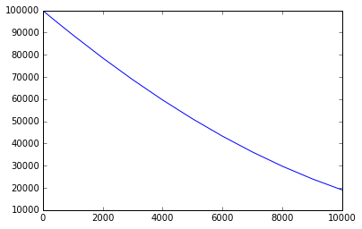

```python
% matplotlib inline
#This is for making plots inline
plt.plot(Z,P,label='P') #Technically correct, but Intuitively incorrect
```

For this problem, Pressure should be in X axis and Altitude in Y axis (For realistic sense)

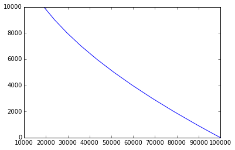

```python
plt.plot(P,Z,label='P')
```

Now, This looks easy to visualize. Remember that you should not stick to conventional X, Y axis. It may not make sense all the time!

## Plots having same x axis but different y axis?

This kind of issue often comes. To sort this out, make use of the axis properties.

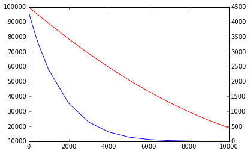

```python
fig, ax1 = plt.subplots() # Extracts the figure and axis parameters from plot

ax2 = ax1.twinx()         # Makes a twin of the X axis.

ax1.plot(Z, P, 'r')       # First Plot  - red colour
ax2.plot(Z, es, 'b')      # Second Plot - blue colour
```

Now, this is nice!

## Plots having same y axis, but different x axis?

This again is possible, but not always common

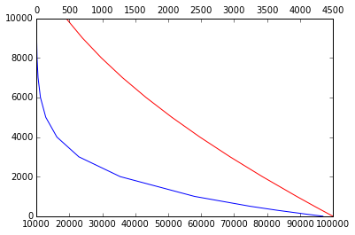

```python
fig, ax1 = plt.subplots() # Extracts the figure and axis parameters from plot

ax2 = ax1.twiny()         # Makes a twin of the Y axis.

ax1.plot(P, Z, 'r')       # First Plot  - red colour
ax2.plot(es, Z, 'b')      # Second Plot - blue colour
```

### What if I superimpose the plots?

It can turn out to be confusing or messy! The values are not separated in the axis. And mostly, a consolidated range is taken, which is not good for some plots. **However, if the ranges are the same in both the axis, superimposition is the best and simple way**

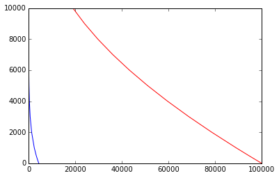

```python
plt.plot(P,Z, 'r')
plt.plot(es,Z, 'b')
```

See the difference? The ranges are consolidated. And not a good idea.

### Where superimposition is good?

If the data ranges are identical/same or comparable, then superimposition avoids a lot of trouble.

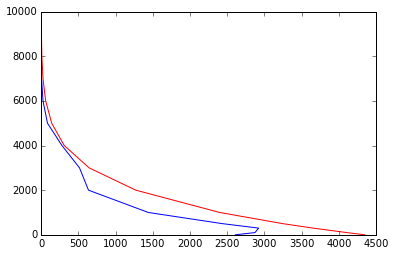

```python
plt.plot(es,Z,'r',label='es')
plt.plot(e,Z,'b',label='e')
```

Now, this makes sense! This way, multiple superimpositions are possible!

# Making Fancier Plots

- Adding grids, legends.,
- Adding labels, Controlling grid points etc.,
- Animation?!
- Saving Figures,
- Other kind of plots,

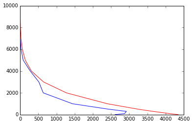

```python
plt.plot(es,Z,'r',label='es')
plt.plot(e,Z,'b',label='e')

# 'b', 'r' stands for red and blue colour lines
# label is the name of the curves
```

Let's make this more fancy shall we?

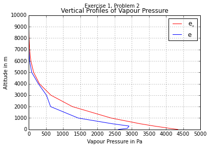

```python
xt = np.linspace(0,5000,11)          # For intentionally creating grids in X axis
yt = np.linspace(0,10000,11)         # For intentionally creating grids in Y axis
plt.plot(es,Z,'r',label='e$_s$')     # Usual Plotting
plt.plot(e,Z,'b',label='e')          # Usual Plotting
plt.xlabel("Vapour Pressure in Pa")  # For adding label to x axis
plt.ylabel("Altitude in m")          # For adding label to y axis
plt.suptitle("Exercise 1, Problem 2")   # Super title!
plt.title("Vertical Profiles of Vapour Pressure")       # Adding title to the Plot
plt.xticks(xt)                       # Making ticks in x axis
plt.yticks(yt)                       # Making ticks in y axis
plt.axis([0, 5000, 0, 10000])        # For making the axis rigid with limits
# Xstart, Xend, Ystart, Yend
plt.legend()                         # To print the legend
plt.grid('on')                       # To get grid lines
plt.savefig('eVsZ.png',format='png',dpi=200)  # Saving figure
```

Now this plot is great! Check your working directory to find a *.png image!

Now that we looked at normal plots, how about bar plots, scatter and histograms?

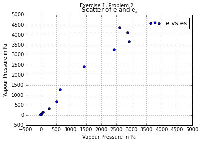

```python
xt = np.linspace(-500,5000,12)        # For intentionally creating grids in X axis
yt = np.linspace(-500,5000,12)        # For intentionally creating grids in Y axis
plt.scatter(e, es,label='e vs es')    # Scatter plot!
plt.xlabel("Vapour Pressure in Pa")   # For adding label to x axis
plt.ylabel("Vapour Pressure in Pa")   # For adding label to y axis
plt.suptitle("Exercise 1, Problem 2") # Super title!
plt.title(" Scatter of e and e$_s$")  # Adding title to the Plot
plt.xticks(xt)                        # Making ticks in x axis
plt.yticks(yt)                        # Making ticks in y axis
plt.axis([-500, 5000, -500, 5000])    # For making the axis rigid with limits
# Xstart, Xend, Ystart, Yend. # Input should be a proper array, tuple or list
plt.legend()                          # To print the legend
plt.grid('on')                        # To get grid lines
plt.savefig('eVSes.png',format='png',dpi=200)  # Saving figure
```

All the fancy features done in plot can also be done here!

# Histograms

We need to know a few things before that! Let's calculate random numbers!

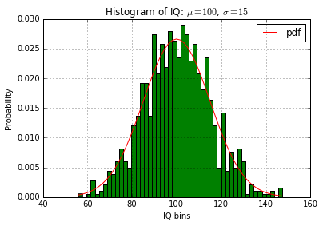

```python
import matplotlib.mlab as mlab
# Numerical Python functions written for compatability with MATLAB commands with the same names.

m , s = 100 , 15
iq = np.random.normal(m, s, 1000)
# Setting a random Human IQ data, normally distributed with mean = 100, sd = 15

num_bins = 50 # Number of groups we want
n, bins, patches = plt.hist(iq, num_bins, normed=1, facecolor='green')
# n = counts in each group
# bins = array of edges. (n groups have n+1 edges)
# patches = other variables for making the histogram plot (not needed)
# normed = 1 or True, then it returns n as fraction. Else, returns n as plain numbers
# Sum of fractions = 1 and, sum of counts = total number of entries
l = mlab.normpdf(bins, m, s) # Creates the pdf of normal distribution
plt.plot(bins, l, 'r', label='pdf')
plt.xlabel('IQ bins')
plt.ylabel('Probability')
plt.title(r'Histogram of IQ: $\mu=100$, $\sigma=15$')
plt.axis()
plt.legend()
plt.grid('on')
plt.savefig('IQ_hist.png',format='png',dpi=200)
```

# Bar Charts

Making Bar Charts is similar!

```python
print np.shape(bins) # Note the size differences
print np.shape(l)
print np.shape(n)
```

```
(51,)
(51,)
(50,)
```

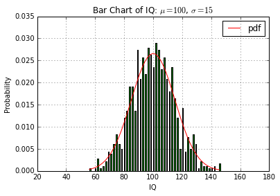

```python
plt.bar(bins[:50],n, facecolor='green') # Creates the bar chart
plt.plot(bins[:50], l[:50], 'r', label='pdf')
plt.xlabel('IQ')
plt.ylabel('Probability')
plt.title(r'Bar Chart of IQ: $\mu=100$, $\sigma=15$')
plt.axis((20, 180, 0.0, 0.035))
plt.legend()
plt.grid('on')
plt.savefig('IQ_bar.png',format='png',dpi=200)
```

You can do a lot of fancy stuff with these plots! Do explore!

# Reading Netcdf files

As a pre-requisite, you need to have the library netcdf4 installed! :)

```python
from netCDF4 import Dataset as dt # note the change of case in netCDF4
import numpy as np
# Dataset is a netcdf object, similar to a dictionary

filestr = 'ncfile2.nc' # This is the file name

ncfile = dt(filestr, 'r') # Create a netcdf object in read mode

print ncfile.variables # To print all the variables

lat = np.array(ncfile.variables['latitude'][:],dtype=np.float32)

'''
Extract a variable named 'latitude' from the netcdf object as a
numpy array, having all it's entries as real numbers of type
float32 (32 bit real numbers).

The numpy array's name is lat
'''

lon = np.array(ncfile.variables['longitude'][:],dtype=np.float32)
t = np.array(ncfile.variables['time'][:],dtype=np.int32)
u = np.array(ncfile.variables['u10'][:],dtype=np.float32)
v = np.array(ncfile.variables['v10'][:],dtype=np.float32)
T = np.array(ncfile.variables['t2m'][:],dtype=np.float32)
al = np.array(ncfile.variables['al'][:],dtype=np.float32)
```

```
OrderedDict([(u'longitude', <type 'netCDF4._netCDF4.Variable'>
float32 longitude(longitude)
    units: degrees_east
    long_name: longitude
unlimited dimensions:
current shape = (360,)
filling off
), (u'latitude', <type 'netCDF4._netCDF4.Variable'>
float32 latitude(latitude)
    units: degrees_north
    long_name: latitude
unlimited dimensions:
current shape = (181,)
filling off
), (u'time', <type 'netCDF4._netCDF4.Variable'>
int32 time(time)
    units: hours since 1900-01-01 00:00:0.0
    long_name: time
    calendar: gregorian
unlimited dimensions: time
current shape = (31,)
filling off
), (u'u10', <type 'netCDF4._netCDF4.Variable'>
int16 u10(time, latitude, longitude)
    scale_factor: 0.000900124425921
    add_offset: -0.513664173541
    _FillValue: -32767
    missing_value: -32767
    units: m s**-1
    long_name: 10 metre U wind component
unlimited dimensions: time
current shape = (31, 181, 360)
filling off
), (u'v10', <type 'netCDF4._netCDF4.Variable'>
int16 v10(time, latitude, longitude)
    scale_factor: 0.00085126849967
    add_offset: 3.20893258108
    _FillValue: -32767
    missing_value: -32767
    units: m s**-1
```

[output cut: 13 more lines]

```
current shape = (31, 181, 360)
filling off
), (u'al', <type 'netCDF4._netCDF4.Variable'>
int16 al(time, latitude, longitude)
    scale_factor: 6.45389521668e-06
    add_offset: 0.281468263912
    _FillValue: -32767
    missing_value: -32767
    units: (0 - 1)
    long_name: Albedo
    standard_name: surface_albedo
unlimited dimensions: time
current shape = (31, 181, 360)
filling off
)])
```

# 2-D Plots

## Contour Plots

They come in 2 varieties.

```
plt.contourf(x,y,z)  # Colour Filled
plt.contour(x,y,z)   # Empty Coloured
```

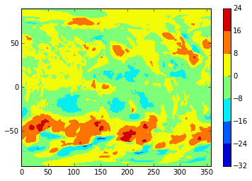

```python
plt.contourf(lon,lat,u[5][:][:]) # Plotting data
plt.colorbar()                   # Making Colour Bar visible
```

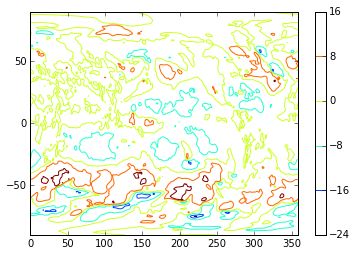

```python
plt.contour(lon,lat,u[5][:][:]) # Plotting data
plt.colorbar()                  # Making Colour Bar visible
```

The only difference between them is that the colour is not filled!

But if you notice something, both the plots are not that attractive!

# 2-D plot Enhancements

To enhance the plots, let's use the best features of both commands.

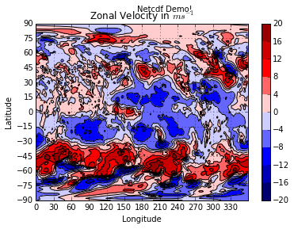

```python
import matplotlib                             # For a few specific purposes
us = np.linspace(-20, 20, 11, endpoint=True)  # For Manual selection of colour bar ranges

plt.contourf(lon,lat,u[5][:][:],us,cmap='seismic')
# Here, usage of 'us' re-distributes the colours in the plot
# cmap = colour map. 'Seismic' is the traditional blue(negative), white(zero), red(positive)
# colour scheme

# plt.contourf(lat2,top2,x.T,40,linewidth=3,cmap='gist_heat_r',vmin=0,vmax=0.0035)
# Here, 40 indicates the number of contours to be placed
# linewidth = 3 sets the thickness of the contour lines to be 3 units
# cmap = 'gist_heat_r' is a single colour heat scheme
# vmin = sets the minimum value to be contoured. Any value below vmin is treated as vmin and below
# vmax = sets the maximum value to be contoured. Any value above vmax is treated as vmax and above

plt.xlabel('Longitude', fontsize=10)  # Label for x axis
plt.ylabel('Latitude', fontsize=10)   # Label for y axis

plt.xticks(np.arange(0,360,30))       # Setting ticks for x-axis gridlines
# x axis will range from 0 to 360 in steps of 30.

plt.yticks(np.arange(-90,100,15))     # Setting ticks for y-axis gridlines
# y axis will range from -90 to 90 in steps of 15

plt.title('Zonal Velocity in $ms^{-1}$') # Title
plt.suptitle("Netcdf Demo!")             # Super title

plt.grid()                            # For enabling grid
plt.axis([0, 360, -90, 90])           # For controlling the axis ranges

plt.colorbar(ticks=us)                # For breaking the colour bar manually

matplotlib.rcParams['contour.negative_linestyle'] = 'solid'
# This sets even the negative values in contour lines to have a solid line
# By default, it is dashed lines for negative values.

plt.contour(lon, lat, u[5][:][:], us, colors='k') # For plotting only contours
# The above is for making negative contours solid instead of dashed
# Adding color = 'k' will make all lines black

#CS = plt.contour(lon, lat, u[5][:][:], us, colors='k')
# CS is a handle for the contour plot here!

#plt.clabel(CS, inline=1, fontsize=10, manual=manual_locations)
# This will label the contours that correspond to the contour of CS with values
# If 'manual' is set to a list of pair of tuples, then the labels will be placed there

#plt.clabel(CS, inline=1, fontsize=10) # enable this for contour labels

#plt.savefig("TvsZ4.png", format='png', dpi=2000) # not recommended for heavy files
# This will produce a very heavy image!

plt.savefig("TvsZ4.eps", format='eps', dpi=200)
# Saving the image as an eps file

#plt.show()
```

Now, the plot looks nice!

# Plot Animation

This will be really useful for observing the data!

How to do?

- The idea is to set a loop running between a finite range.
- Plot the values in each loop and clear them up before plotting the next loop's value.
- Set a pause timer to delay the computation time.

```python
% matplotlib qt
# The above command is to be used only when running in an ipython terminal
# Not needed while running generally
for i in range(0, 31):                                 # Start a loop!
    plt.clf()                                          # Clear the figure
    us = np.linspace(-20, 20, 11, endpoint=True)       # For manual adjustment of contours
    plt.contourf(lon,lat,u[i][:][:],us,cmap='seismic') # Contour plotting the values
    plt.xlabel('Longitude', fontsize=10)               # X axis label
    plt.ylabel('Latitude', fontsize=10)                # Y axis label
    plt.xticks(np.arange(0,360,30))                    # X axis grid lines
    plt.yticks(np.arange(-90,100,15))                  # Y axis grid lines
    plt.title('Zonal Velocity in $ms^{-1}$ at t = '+str(i))
    plt.suptitle("Netcdf Exercise!")                   # Super title
    plt.grid(True)                                     # Enabling gridding
    plt.axis((0, 360, -90, 90))                        # Making axis rigid
    plt.colorbar(ticks=us)                             # Enabling colour bar with user defined breaks
    matplotlib.rcParams['contour.negative_linestyle'] = 'solid'
    plt.contour(lon, lat, u[i][:][:], us, colors='k')  # For plotting contours
    plt.pause(0.001)                                   # To delay the process.
print "Do this and see what happens!"
```

```
Do this and see what happens!
```

Pretty cool huh?! You can make a video too!

## Animation

What does it need?

- A dummy figure
- A rigid axis
- matplotlib.animation
- An animation function

```python
import numpy as np
from netCDF4 import Dataset as dt
import matplotlib
from matplotlib import pyplot as plt
from matplotlib import animation as anim  # This is vital!

filestr = 'ncfile2.nc' # This is the file name
ncfile = dt(filestr, 'r') # Create a netcdf object in read mode
lat = np.array(ncfile.variables['latitude'][:],dtype=np.float32)

lon = np.array(ncfile.variables['longitude'][:],dtype=np.float32)
u = np.array(ncfile.variables['u10'][:],dtype=np.float32)
us = np.linspace(-20, 20, 11, endpoint=True)

fig = plt.figure()                        # Create a dummy figure
ax = plt.axes([0, 360, -90, 90])          # Set the axis rigid
matplotlib.rcParams['contour.negative_linestyle'] = 'solid'

# This is an initialization function
#def init():
#    cont.set_data([],[],[])
#    return cont,

# This is the animation function
def animate(i):
    plt.clf()
    #print i
    cont = plt.contourf(lon, lat, u[i][:][:], us, cmap='seismic')
    plt.title('Zonal Velocity in $ms^{-1}$ at t = '+str(i))
    plt.xlabel('Longitude')
    plt.ylabel('Latitude')
    plt.xticks(np.arange(0,360,30))
    plt.yticks(np.arange(-90,100,15))
    plt.suptitle("Netcdf Exercise")
    plt.grid(True)
    plt.colorbar(ticks=us)
    plt.contour(lon, lat, u[i][:][:], us, colors='k')  # For plotting contours
    #plt.pause(0.001) # Do not do this while animating! Memory Overload!
    return cont,    # Return the handle

ani = anim.FuncAnimation(fig, animate, interval = 1000, frames=31)  # Invoke the animation function.
# Pass the animate function as an argument.
# Interval sets the time period between the frames in milli-second
# fig is the figure handle
# init_func is the initialization function
# Set the number of frames needed. This data set has 31 time snaps!
# Hence, set frames = 31

ani.save('animation.mp4',fps=1)
# To save the video
# fps = frames per second. Choose a value based on frames on top!
```

# Interpolation

This is possible with the help of interpolation operation in scipy

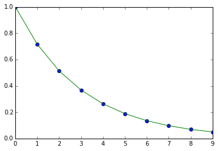

```python
% matplotlib inline
import numpy as np
from scipy import interpolate

mat1 = {}

x = np.arange(0.0, 10.0)
y = np.exp(-x/3.0)
f = interpolate.interp1d(x,y) # Set an interpolation function

x1 = np.linspace(0, 9.0, 100)
y1 = f(x1)                    # Interpolated variable for y

mat1['x'] = x
mat1['y'] = y

plt.plot(x, y, 'o', x1, y1, '-')
```

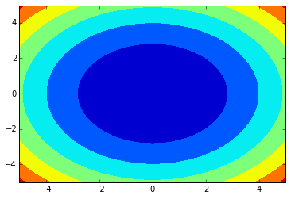

```python
% matplotlib inline
x = np.arange(-5.01, 5.01, 0.25)
y = np.arange(-5.01, 5.01, 0.25)

xx, yy = np.meshgrid(x, y) # Generates a 2-D mesh

z = xx**2 + yy**2
f = interpolate.interp2d(xx, yy, z, kind='cubic')

x1 = np.arange(-5.01, 5.01, 1e-2)
y1 = np.arange(-5.01, 5.01, 1e-2)

z1 = f(x1, y1)

mat1['x1'] = x1
mat1['y1'] = y1
mat1['z1'] = z1

plt.contourf(x, y, z)
```

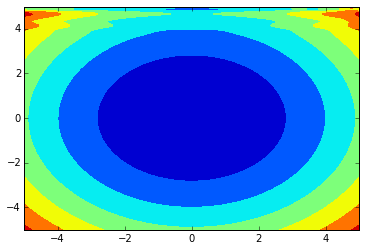

```python
plt.contourf(x1, y1, z1)
```

Except for a few distortions, the values are fine!

# Re-gridding Data

Applicable for 2D data

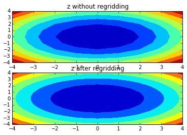

```python
import numpy as np
# Step 0: Import interpolate option
from scipy import interpolate as inter

# Step 1: Set a value to be regridded along with mesh

x = np.linspace(-4, 4, 9)
y = np.linspace(-4, 4, 9)
x1, y1 = np.meshgrid(x, y)

z1 = x1**2 + y1**2

# Step 2: Create a new range for the regridding along with mesh

xi = np.linspace(-4, 4, 17)
yi = np.linspace(-4, 4, 17)
x2, y2, = np.meshgrid(xi, yi)

# Step 3: Create a temporary variable
tck = inter.bisplrep(x1, y1, z1, s=1)
# Bivariate B-spline representation of surface
# u is a smoothing factor

# Step 4: Interpolate the values using the variable above
z2 = inter.bisplev(xi, yi, tck)

import matplotlib.pyplot as plt
plt.subplot(211)
plt.contourf(x1, y1, z1)
plt.title('z without regridding')
plt.subplot(212)
plt.contourf(x2, y2, z2)
plt.title('z after regridding')
plt.show()
```

Do you see any difference? Regridding takes some time. So, it is better your memory is less loaded before attempting this.

# Stream line plots

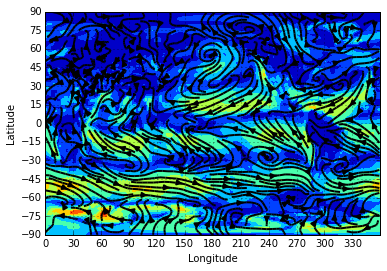

```python
% matplotlib inline
um = np.mean(u, axis=0)
vm = np.mean(v, axis=0)

uv = (um**2 + vm**2)**0.5

plt.contourf(lon, lat, uv)
#plt.contour(lon, lat, uv)
plt.xticks(np.arange(0,360,30))
plt.yticks(np.arange(-90,100,15))
plt.xlabel('Longitude', fontsize=10)  # X axis label
plt.ylabel('Latitude', fontsize=10)  # Y axis label
plt.axis([0, 360, -90, 90])
plt.grid('on')
plt.streamplot(lon, lat, um, vm, density=2, linewidth=2, color='k')
plt.savefig('Stream.eps', format='eps', dpi=2000)
```

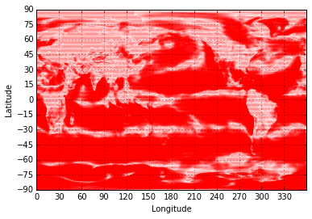

```python
% matplotlib qt
Q = plt.quiver(lon, lat, um, vm, pivot='mid', color='r', units='inches', scale = 100)
plt.xticks(np.arange(0,360,30))
plt.yticks(np.arange(-90,100,15))
plt.xlabel('Longitude', fontsize=10)  # X axis label
plt.ylabel('Latitude', fontsize=10)  # Y axis label
plt.axis([0, 360, -90, 90])
plt.quiverkey(Q, 330, -75, U = 2, label = 'm/s')
plt.grid('on')
```

## Saving data to .mat files

```
import scipy.io as sio

filestr = 'sample.mat'

sio.savemat(filestr, mat1)
```

## Reading data from .mat files

```
mat = sio.loadmat('sample.mat')

var1 = mat['var1']
```